# Exercices Session IV: Anova

Applied Biostatistics Course with R

Author

Biostatistics Support and Research Unit, IGTP

# Spider

24 arachnophobes were used in all. 12 were asked to play with a big hairy tarantula spider with big fangs and an evil look. Their subsequent anxiety was measured. The remaining 12 were shown only picture of the same hairy tarantula. Again, the anxiety was measured.

**1.** Load the “spider” dataframe from the WRS2 package, visualise it and format variables according to their type.

```r
library(WRS2)

data("spider")

#View(spider)

spider$Group<-factor(spider$Group)
```

**2.** Describe and graph levels of anxiety by study group

```r
library(gtsummary)
library(ggplot2)
library(dplyr)

spider |>
    gtsummary::tbl_summary(
        by=Group,
        type = all_continuous() ~ "continuous2",
        statistic=all_continuous()~c("{mean} ({sd})",
        "{median} ({p25}, {p75})"),
        digits = all_continuous() ~ 2
        )
```

| **Characteristic** | **Picture** N = 12 | **Real Spider** N = 12 |
| --- | --- | --- |
| Anxiety |  |  |
| Mean (SD) | 40.00 (9.29) | 47.00 (11.03) |
| Median (Q1, Q3) | 40.00 (32.50, 47.50) | 50.00 (37.00, 55.00) |

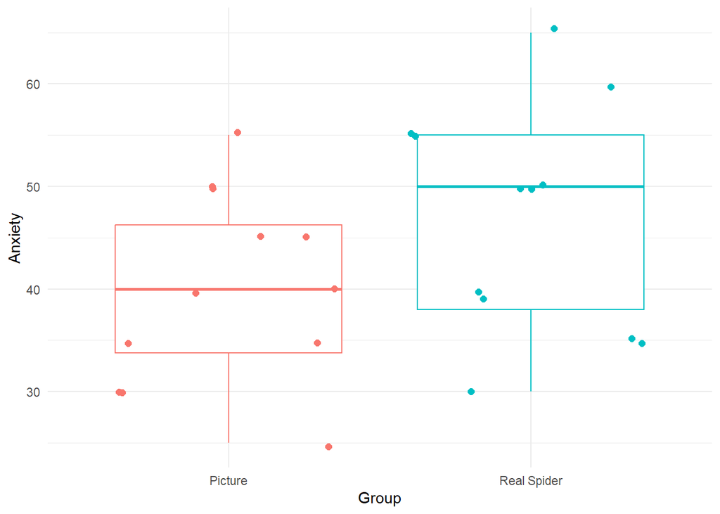

```r
ggplot(spider, aes(x = Group, y =Anxiety,color=Group)) +
  geom_boxplot()+
  geom_jitter(size = 2)+
  labs(x = "Group", y = "Anxiety") +
  theme_minimal() +
  theme(legend.position = "none")
```

**3.** Evaluate one-way ANOVA conditions.

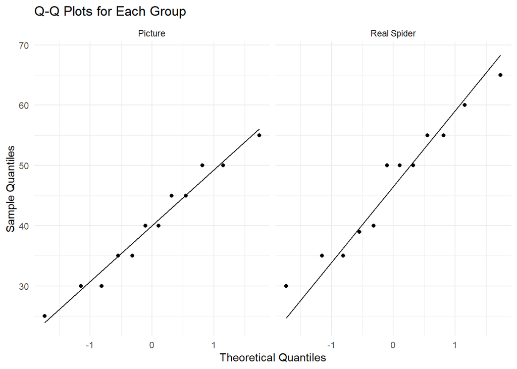

```r
#QQplot
ggplot(spider, aes(sample = Anxiety)) +
  geom_qq() +
  geom_qq_line() +
  labs(title = "Q-Q Plots for Each Group", x = "Theoretical Quantiles", y = "Sample Quantiles") +
  facet_wrap(~Group) +
  theme_minimal()
```

```r
#Shapiro-Wilk
spider |>
  group_by(Group) |>
  summarise(p_value = shapiro.test(Anxiety)$p.value)
```

```
# A tibble: 2 × 2
  Group       p_value
  <fct>         <dbl>
1 Picture       0.852
2 Real Spider   0.621
```

```r
# Levene Test
library(car)
leveneTest(Anxiety ~ Group, data = spider)
```

```
Levene's Test for Homogeneity of Variance (center = median)
      Df F value Pr(>F)
group  1  0.2991   0.59
      22
```

```r
# Bartlett Test
bartlett.test(Anxiety ~ Group, data = spider)
```

```
    Bartlett test of homogeneity of variances

data:  Anxiety by Group
Bartlett's K-squared = 0.30702, df = 1, p-value = 0.5795
```

**4.** Is the level of anxiety higher in people who have had contact with a real tarantula?

```r
# ANOVA: dependent ~ independent
model_anova <- aov(Anxiety ~ Group, data = spider)

# Arrange results
results_anova <- broom::tidy(model_anova)
results_anova$term<-c("Between-groups","Within-groups")
names(results_anova)<-c("Terms","df","SS","MSQ","F","P-value")

# Tabulate results
results_anova |>
  gt::gt() |>
  gt::fmt_number(decimals = 3) |>
  gt::tab_header(title = "Spider: 1-way Anova")
```

Spider: 1-way Anova

| Terms | df | SS | MSQ | F | P-value |
| --- | --- | --- | --- | --- | --- |
| Between-groups | 1.000 | 294.000 | 294.000 | 2.827 | 0.107 |
| Within-groups | 22.000 | 2,288.000 | 104.000 | NA | NA |

**5.** Estimate and plot the anxiety marginal means.

```r
library(emmeans)

# Estimated marginal means
emm <- emmeans(model_anova, ~ Group)
print(emm)
```

```
 Group       emmean   SE df lower.CL upper.CL
 Picture         40 2.94 22     33.9     46.1
 Real Spider     47 2.94 22     40.9     53.1

Confidence level used: 0.95
```

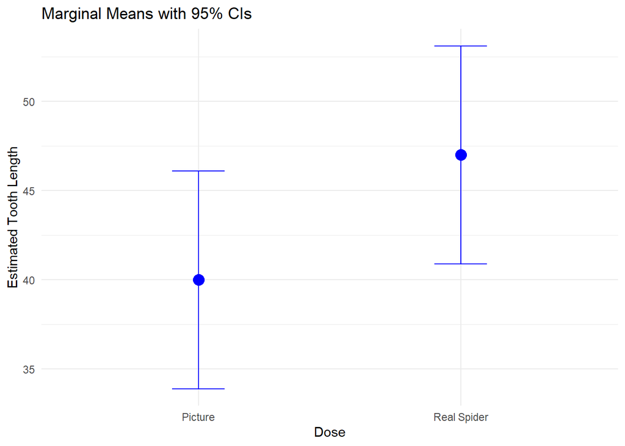

```r
# Plot estimated marginal means with confidence intervals
ggplot(as.data.frame(emm),  aes(x = Group, y = emmean, ymin = lower.CL, ymax = upper.CL)) +
  # Mean points
  geom_point(size = 4, color = "blue") +
  # Confidence intervals
  geom_errorbar(width = 0.2, color = "blue") +
  labs(title = "Marginal Means with 95% CIs",
      x = "Dose",
      y = "Estimated Tooth Length") +
  theme_minimal()
```

# Hangover

In a study on the effect of consuming alcohol, hangover symptoms were measured for two independent groups, with each subject consuming alcohol and being measured on three different occasions. One group consisted of sons of alcoholics and the other was a control group.

**1.** Load the “hangover” dataframe from the WRS2 package, visualise it and format variables according to their type.

```r
library(WRS2)

data("hangover")

#View(hangover)

hangover$id<-factor(hangover$id)
hangover$group<-factor(hangover$group)
hangover$time<-factor(hangover$time)
```

**2.** Describe and plot number of hangover symptoms by time and study group

```r
library(gtsummary)
library(ggplot2)
library(dplyr)

hangover |>
  select(-id) |>
  tbl_strata(
    strata = group,  .tbl_fun =  ~ .x |>
        tbl_summary(by = time,
        missing = "no",
        type = symptoms ~ "continuous2",
        statistic=all_continuous()~c("{mean} ({sd})", "{median} ({p25}, {p75})"),
        digits = all_continuous() ~ 2)
        )
```

| **Characteristic** | **control** **1** N = 20 | **control** **2** N = 20 | **control** **3** N = 20 | **alcoholic** **1** N = 20 | **alcoholic** **2** N = 20 | **alcoholic** **3** N = 20 |
| --- | --- | --- | --- | --- | --- | --- |
| symptoms |  |  |  |  |  |  |
| Mean (SD) | 7.45 (11.30) | 9.90 (10.67) | 7.75 (6.97) | 2.90 (7.53) | 3.85 (5.27) | 5.50 (10.58) |
| Median (Q1, Q3) | 2.50 (0.00, 11.00) | 5.50 (2.50, 14.00) | 6.50 (1.50, 12.50) | 0.00 (0.00, 1.50) | 1.50 (0.00, 7.00) | 1.00 (0.00, 4.50) |

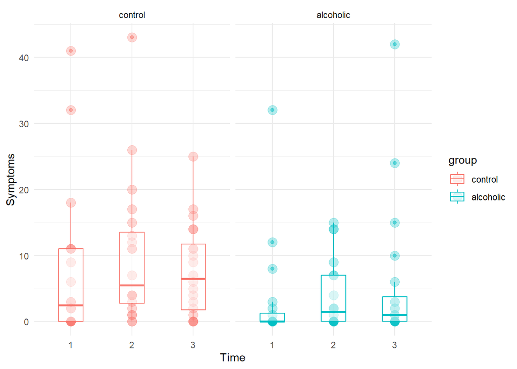

```r
# Plot
ggplot(hangover, aes(x = time, y = symptoms , color = group)) +
  geom_point(size = 4, alpha = 0.3) +
  geom_boxplot(aes(x = time, group = interaction(time, group)), width = 0.4, alpha = 0.5) +
  facet_wrap(~group) +
  labs(x = "Time", y = "Symptoms") +
  theme_minimal()
```

**3.** Evaluate repeated measures ANOVA conditions.

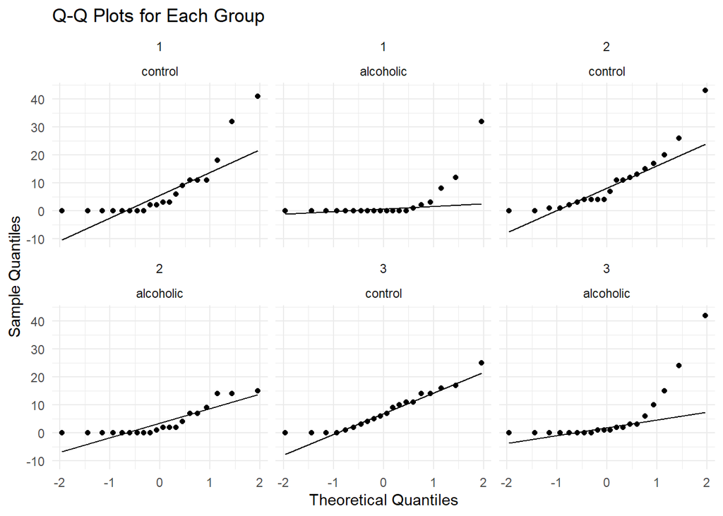

```r
#QQplot
ggplot(hangover, aes(sample = symptoms)) +
  geom_qq() +
  geom_qq_line() +
  facet_wrap(~time*group) +
  labs(title = "Q-Q Plots for Each Group",
       x = "Theoretical Quantiles",
       y = "Sample Quantiles") +
  theme_minimal()
```

```r
library(ez)
anova_test <- ezANOVA(
  data = hangover,
  dv = symptoms,
  wid = id,
  within = time,
  between = group,
  detailed = TRUE
)
anova_test[2:3]
```

```
$`Mauchly's Test for Sphericity`
      Effect         W        p p<.05
3       time 0.9448602 0.350187
4 group:time 0.9448602 0.350187

$`Sphericity Corrections`
      Effect       GGe     p[GG] p[GG]<.05       HFe     p[HF] p[HF]<.05
3       time 0.9477417 0.4080019           0.9960507 0.4122386
4 group:time 0.9477417 0.3786932           0.9960507 0.3820772
```

**4.** Do symptoms increase over time? Do the symptoms differ between the study groups?

```r
# ANOVA: dependent ~ independent
model_anova_rm <- aov(symptoms ~ time + group + Error(id/time), data = hangover)

# Arrange results
results_anova_rm <- broom::tidy(model_anova_rm)
results_anova_rm$term<-c("Group","Residuals","Time","Residual")
names(results_anova_rm)<-c("Stratum","Term","df","SS","MSQ","F","P-value")


# Tabulate results
results_anova_rm |>
  gt::gt() |>
  gt::fmt_number(decimals = 3) |>
  gt::tab_header(title = "Weigth: repeated measure Anova")
```

Weigth: repeated measure Anova

| Stratum | Term | df | SS | MSQ | F | P-value |
| --- | --- | --- | --- | --- | --- | --- |
| id | Group | 1.000 | 550.408 | 550.408 | 3.277 | 0.078 |
| id | Residuals | 38.000 | 6,382.517 | 167.961 | NA | NA |
| id:time | Time | 2.000 | 67.400 | 33.700 | 0.896 | 0.412 |
| id:time | Residual | 78.000 | 2,932.600 | 37.597 | NA | NA |

**5.** Estimate and plot the group marginal means over time.

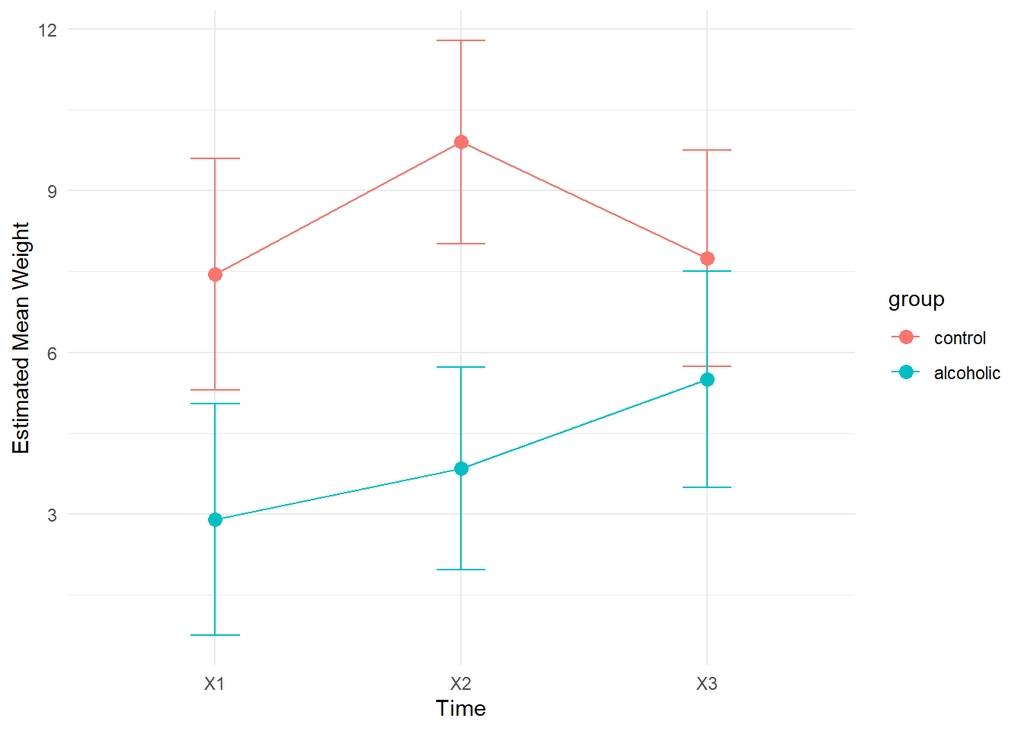

```r
library(emmeans)
library(afex)

model_afex <- aov_car(symptoms ~ time + group + Error(id/time), data = hangover)
emm_results <-emmeans(model_afex, ~ time | group)

# Plot estimated marginal means with confidence intervals

ggplot(as.data.frame(emm_results),aes(x = time, y = emmean, color = group, group = group)) +
  geom_point(size = 3) +
  geom_line() +
  geom_errorbar(aes(ymin = emmean - SE, ymax = emmean + SE), width = 0.2) +
  labs(x = "Time", y = "Estimated Mean Weight") +
  theme_minimal()
```

**6.** Do time and study group interact?

```r
# ANOVA: dependent ~ independent
model_anova_rm2 <- aov(symptoms ~ time * group + Error(id/time), data = hangover)

# Arrange results
results_anova_rm2 <- broom::tidy(model_anova_rm2)
results_anova_rm2$term<-c("Group","Residuals","Time","Interaction","Residual")
names(results_anova_rm2)<-c("Stratum","Term","df","SS","MSQ","F","P-value")


# Tabulate results
results_anova_rm2 |>
  gt::gt() |>
  gt::fmt_number(decimals = 3) |>
  gt::tab_header(title = "Weigth: repeated measure Anova")
```

Weigth: repeated measure Anova

| Stratum | Term | df | SS | MSQ | F | P-value |
| --- | --- | --- | --- | --- | --- | --- |
| id | Group | 1.000 | 550.408 | 550.408 | 3.277 | 0.078 |
| id | Residuals | 38.000 | 6,382.517 | 167.961 | NA | NA |
| id:time | Time | 2.000 | 67.400 | 33.700 | 0.896 | 0.413 |
| id:time | Interaction | 2.000 | 73.267 | 36.633 | 0.974 | 0.382 |
| id:time | Residual | 76.000 | 2,859.333 | 37.623 | NA | NA |